# Mapping_Basics_World

Julia Christensen

March 25, 2019

# 1) SET UP

## 1.1. General Set Up

```r
### Clear global environment
rm(list=ls())
```

## 1.2. Libraries

```r
### Download Libraries
library(pacman)
p_load(tidyverse, data.table, rmarkdown, knitr, tinytex, magrittr,
       gplots, #for heatmaps
       viridis, RColorBrewer, scales, #good colors
       grDevices, graphics,
       mapproj, ggmap,
       rgdal, tmap,
       maptools, tmaptools,
       wbstats, WDI, #use to download world bank data
       sf,
       rnaturalearthdata #shapefile for world map
       )
```

Notes:

- Not all of these packages are used in this file. In general, it’s not a good idea to have a bunch of extra packages (sometimes two packages have a function with the same name, which causes chaos). However, I don’t remember which ones are necessary.

# 2) DOWNLOAD SHAPEFILE

## 2.1. Use “rnaturalearth” to download shapefile for world

```r
world_geo <- rnaturalearth::ne_countries(scale = 50, returnclass = "sp")
```

## 2.2. Save tidied shapefile

```r
# Create map dataframe
world_geo_tidy <- data.table(broom::tidy(world_geo))

# Look at map dataframe (Note: no FIPS column)
world_geo_tidy %>% head()
```

```
##         long      lat order  hole piece group id
## 1: -69.89912 12.45200     1 FALSE     1   0.1  0
## 2: -69.89570 12.42300     2 FALSE     1   0.1  0
## 3: -69.94219 12.43853     3 FALSE     1   0.1  0
## 4: -70.00415 12.50049     4 FALSE     1   0.1  0
## 5: -70.06611 12.54697     5 FALSE     1   0.1  0
## 6: -70.05088 12.59707     6 FALSE     1   0.1  0
```

Note(s):

- In general, it’s bad practice to turn off warnings for a chunk, but I’ve done so here because printing the warnings makes R take (a lot) longer. This warning is only about coercing factors and characters.
- For chunk options, see https://rmarkdown.rstudio.com/lesson-3.html

## 2.3. Crosswalk for census id and FIPS

```r
# Save data in data slot
crosswalk <- world_geo@data

# Save row IDs in a column
crosswalk <- cbind(id=rownames(crosswalk), crosswalk)
```

# 3) DOWNLOAD WORLD BANK DATA

## 3.1. Select variables to download

```r
# Set Variables
selectvars <- c(
  # Maternal mortality ratio (modeled estimate, per 100,000 live births)
  "SH.STA.MMRT",
  # Births attended by skilled health staff (% of total)
  "SH.STA.BRTC.ZS",
  # Sex ratio at birth (male births per female births)
  "SP.POP.BRTH.MF",
  # Adolescent fertility rate (births per 1,000 women ages 15-19)
  "SP.ADO.TFRT",
  # Mortality rate, under-5 (per 1,000 live births)
  "SH.DYN.MORT",
  # Mortality rate, infant (per 1,000 live births)
  "SP.DYN.IMRT.IN",
  # School enrollment, primary (gross), gender parity index (GPI)
  "SE.ENR.PRIM.FM.ZS",
  # School enrollment, secondary (gross), gender parity index (GPI)
  "SE.ENR.SECO.FM.ZS",
  # School enrollment, tertiary (gross), gender parity index (GPI)
  "SE.ENR.TERT.FM.ZS",
  # Pregnant women receiving prenatal care (%)
  "SH.STA.ANVC.ZS",
  # Women who were first married by age 15 (% of women ages 20-24
  "SP.M15.2024.FE.ZS",
  # Female genital mutilation prevalence (%)
  "SH.STA.FGMS.ZS",
  # Women making their own informed decisions regarding sexual relations, contraceptive use and a
  # reproductive health care  (% of women age 15-49)
  "SG.DMK.SRCR.FN.ZS",
  # Women who believe a husband is justified in beating his wife when she argues with him (%)
  "SG.VAW.ARGU.ZS")
```

## 3.2. Detour: How to evalute packages

There are at least two packages for downloading world bank data directly into R:

```r
?wb
```

```
## starting httpd help server ... done
```

```r
?WDI
```

wb() - This function downloads the requested information using the World Bank API

WDI() - Downloads the requested data by using the World Bank’s API, parses the resulting XML file, and formats it in long country-year format.

### 3.2.1. Download data

```r
# Use wbstats
wb_wb <- wbstats::wb(country = "countries_only",
                     indicator = selectvars,
                     start=2010,
                     end=2015,
                     return_wide=TRUE)
# Use WDI
wb_WDI <- WDI::WDI(country="all",
                   indicator = selectvars,
                   start=2010,
                   end=2015,
                   extra=TRUE #returns extra variables such as region, iso3c code, and incomeLevel
                   )
```

### 3.2.2. Compare Packages

```r
wb_wb %>% glimpse()
```

```
## Observations: 1,239
## Variables: 18
## $ iso3c             <chr> "ABW", "ABW", "ABW", "ABW", "ABW", "ABW", "AFG", ...
## $ date              <chr> "2010", "2011", "2012", "2013", "2014", "2015", "...
## $ iso2c             <chr> "AW", "AW", "AW", "AW", "AW", "AW", "AF", "AF", "...
## $ country           <chr> "Aruba", "Aruba", "Aruba", "Aruba", "Aruba", "Aru...
## $ SE.ENR.PRIM.FM.ZS <dbl> 0.98696, 0.97171, 1.02508, 0.97810, 0.96864, NA, ...
## $ SE.ENR.SECO.FM.ZS <dbl> 1.05181, 1.05607, 1.01760, NA, NA, NA, 0.49785, 0...
## $ SE.ENR.TERT.FM.ZS <dbl> 1.41237, 1.49926, 1.49460, 2.20461, 2.27028, 2.26...
## $ SG.DMK.SRCR.FN.ZS <dbl> NA, NA, NA, NA, NA, NA, NA, NA, NA, NA, NA, NA, N...
## $ SG.VAW.ARGU.ZS    <dbl> NA, NA, NA, NA, NA, NA, NA, NA, NA, NA, NA, 59.2,...
## $ SH.DYN.MORT       <dbl> NA, NA, NA, NA, NA, NA, 88.0, 84.1, 80.5, 76.9, 7...
## $ SH.STA.ANVC.ZS    <dbl> NA, NA, NA, NA, NA, NA, 59.6, 47.9, 51.2, NA, 63....
## $ SH.STA.BRTC.ZS    <dbl> NA, NA, NA, NA, NA, NA, 34.3, 38.6, 39.9, NA, 45....
## $ SH.STA.FGMS.ZS    <dbl> NA, NA, NA, NA, NA, NA, NA, NA, NA, NA, NA, NA, N...
## $ SH.STA.MMRT       <dbl> NA, NA, NA, NA, NA, NA, 954, 905, 858, 810, 786, ...
## $ SP.ADO.TFRT       <dbl> 30.6520, 29.5820, 28.5120, 27.3444, 26.1768, 25.0...
## $ SP.DYN.IMRT.IN    <dbl> NA, NA, NA, NA, NA, NA, 64.3, 61.9, 59.5, 57.3, 5...
## $ SP.M15.2024.FE.ZS <dbl> NA, NA, NA, NA, NA, NA, NA, NA, NA, NA, NA, 8.8, ...
## $ SP.POP.BRTH.MF    <dbl> 1.050, 1.050, 1.050, 1.050, 1.050, 1.050, 1.060, ...
```

```r
wb_WDI %>% glimpse()
```

```
## Observations: 1,584
## Variables: 24
## $ iso2c             <chr> "1A", "1A", "1A", "1A", "1A", "1A", "1W", "1W", "...
## $ country           <chr> "Arab World", "Arab World", "Arab World", "Arab W...
## $ year              <int> 2012, 2010, 2013, 2011, 2014, 2015, 2010, 2013, 2...
## $ SH.STA.MMRT       <dbl> 163, 174, 157, 167, 156, 153, 248, 229, 241, 224,...
## $ SH.STA.BRTC.ZS    <dbl> NA, NA, NA, NA, 83.04140, NA, NA, NA, NA, 80.1056...
## $ SP.POP.BRTH.MF    <dbl> 1.052956, 1.052850, 1.052754, 1.052911, 1.052509,...
## $ SP.ADO.TFRT       <dbl> 49.79083, 49.96690, 49.34496, 49.86689, 48.85366,...
## $ SH.DYN.MORT       <dbl> 40.25994, 42.73769, 39.16085, 41.41839, 38.20436,...
## $ SP.DYN.IMRT.IN    <dbl> 30.11056, 31.81526, 29.35986, 30.90711, 28.71359,...
## $ SE.ENR.PRIM.FM.ZS <dbl> 0.92944, 0.92290, 0.93089, 0.91804, 0.93668, 0.93...
## $ SE.ENR.SECO.FM.ZS <dbl> 0.93028, 0.92945, 0.92914, 0.93191, 0.92385, 0.92...
## $ SE.ENR.TERT.FM.ZS <dbl> 1.03854, 1.04136, 1.03392, 1.04497, 1.03775, 1.06...
## $ SH.STA.ANVC.ZS    <dbl> NA, NA, NA, NA, 83.82084, NA, NA, NA, NA, 86.1748...
## $ SP.M15.2024.FE.ZS <dbl> NA, NA, NA, NA, NA, NA, NA, NA, NA, NA, NA, NA, N...
## $ SH.STA.FGMS.ZS    <dbl> NA, NA, NA, NA, NA, NA, NA, NA, NA, NA, NA, NA, N...
## $ SG.DMK.SRCR.FN.ZS <dbl> NA, NA, NA, NA, NA, NA, NA, NA, NA, NA, NA, NA, N...
## $ SG.VAW.ARGU.ZS    <dbl> NA, NA, NA, NA, NA, NA, NA, NA, NA, NA, NA, NA, N...
## $ iso3c             <fct> ARB, ARB, ARB, ARB, ARB, ARB, WLD, WLD, WLD, WLD,...
## $ region            <fct> Aggregates, Aggregates, Aggregates, Aggregates, A...
## $ capital           <fct> , , , , , , , , , , , , , , , , , , , , , , , , ,
## $ longitude         <fct> , , , , , , , , , , , , , , , , , , , , , , , , ,
## $ latitude          <fct> , , , , , , , , , , , , , , , , , , , , , , , , ,
## $ income            <fct> Aggregates, Aggregates, Aggregates, Aggregates, A...
## $ lending           <fct> Aggregates, Aggregates, Aggregates, Aggregates, A...
```

## 3.3. Select world bank data to map

```r
# (Optional) Rename selected results
wb_dat <- wb_wb

# Drop other results
rm(wb_wb, wb_WDI)
```

# 4) MERGE

# 4.1. Merge WB with Croswalk

```r
# Subset crosswalk to only needed variables
crosswalk %<>% select(id, iso_a2)

# Use crosswalk to merge race data with shapefile IDs
wb_wID <- left_join(x = crosswalk,
                    y = wb_dat,
                    by = c("iso_a2" = "iso2c"))
```

# 4.1. Merge WB with Shapefile

```r
# Merge census data with map dataframe
map_df <- left_join(x = world_geo_tidy,
                    y = wb_wID,
                    by = "id")
```

# 5) GENERATE MAPS

## 5.1. Rename vars

```r
map_df %<>%
  # Rename variables
    rename("Sex_ratio"="SP.POP.BRTH.MF",
           "Prenatal"="SH.STA.ANVC.ZS",
           "Child_marriage" ="SP.M15.2024.FE.ZS",
           "Infant_mortality"="SP.DYN.IMRT.IN")
```

## 5.2. Plot one variable

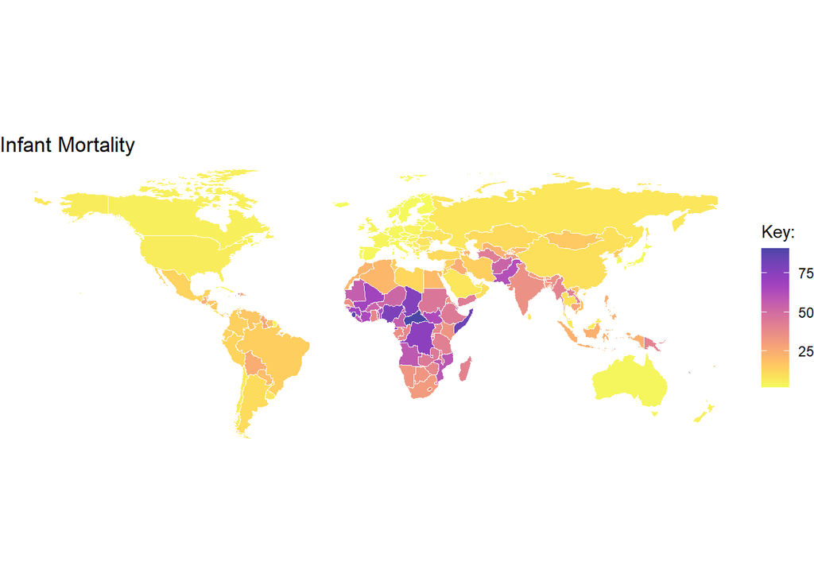

```r
# Generate map of 2010 data
map_df %>%
  filter(date == 2015) %>%
  ggplot(aes(x=long, y=lat, group=group)) +
  # Plot data for each county (based on fill_var)
    geom_polygon(aes_string(fill = "Infant_mortality"), colour="white", size=.1) +
  # See note below (related to how 2D map created for 3D globe)
    coord_quickmap() +
  # Titles / labels (based on txt_var)
    labs(title=paste0("Infant Mortality"), x="", y="") +
  # Theme
    theme_void() +
  # Fill
    scale_fill_viridis(alpha = .75, begin = 0, end = 1,
                       direction = -1, discrete = FALSE, option = "C",
                       #trans=log10_trans(),
                       name = "Key:")
```